*— title: ‘Determining wine quality: A machine learning approach’ author: “Justo AndrÃ©s Manrique Urbina” date: “17 de junio de 2019” output: word_document: default pdf_document: default —

# Introduction

This document is the capstone project in the Data Science Professional Certificate program. As part of this program, we’ve been tasked to create our own project using a curated database. I’ve chosen a red wine quality database, which can be found in the following URL: https://archive.ics.uci.edu/ml/datasets/Wine+Quality. According to data description, this database is related to red variant of the Portuguese “Vinho Verde” wine. The purpose will give to this database is to predict the quality of a specific wine, given it’s variables (we’ll put more detail into this later).

This project has the following structure:

- Exploratory Data Analysis: We’ll understand the nature of our variables, the variable we want to predict and its relationship.
- Model Iteration: Given our performance metric, we’ll compare different models and see which one is a better fit. ** Results Discussion: We’ll determine what model is best and what are the next steps to improve our prediction.

Let’s start working!

First, let’s set up our environment. We’ll load required libraries, set up working directory and do some minimal cleansing of data (clean the headers and creating training - test partition):

```r
# Library Load

library(tidyverse)
library(caret)
library(e1071)
library(corrplot)

# Environment cleaning and seeding setting

rm(list=ls())
set.seed(140)
setwd("C:/Users/jaman/Documents/GitHub/jm-learning/data-science-cyo/data")

## Data loading
w_red <- read_delim("winequality-red.csv", ";", escape_double = FALSE, trim_ws = TRUE)
colnames(w_red) <- make.names(colnames(w_red))

## Creating partition
index = createDataPartition(w_red$quality,times=1,p=0.75, list = F)
w_red_train = w_red[index,]
w_red_test = w_red[-index,]
```

# Exploratory Data Analysis

- Understanding data requires some special thought on what’s the data structure and what does each data point represents. For this, we get a sense of our data structure by using formula glimple from dplyr package. After this, we understand data nature from the paper it’s originated (http://www3.dsi.uminho.pt/pcortez/wine5.pdf, page 23). From this understanding, we get the following ideas:
- All of our attributes are continuous.
- Not all variables have the same scale: sulfur dioxide variables are in milligrams, and the other ones are in grams.Due to this, we can see that these variables have bigger means and maximums than the other variables.
- The variable ‘quality’, which is the variable we want to predict, can be treated or as a numeric or ordinal value. This means we can do a regression or classification model. We’ll treat this variable as numeric.

```r
glimpse(w_red_train)
```

```
## Observations: 1,200
## Variables: 12
## $ fixed.acidity        <dbl> 7.4, 7.8, 7.8, 7.4, 7.4, 7.9, 7.3, 7.8, 7...
## $ volatile.acidity     <dbl> 0.700, 0.880, 0.760, 0.700, 0.660, 0.600,...
## $ citric.acid          <dbl> 0.00, 0.00, 0.04, 0.00, 0.00, 0.06, 0.00,...
## $ residual.sugar       <dbl> 1.9, 2.6, 2.3, 1.9, 1.8, 1.6, 1.2, 2.0, 6...
## $ chlorides            <dbl> 0.076, 0.098, 0.092, 0.076, 0.075, 0.069,...
## $ free.sulfur.dioxide  <dbl> 11, 25, 15, 11, 13, 15, 15, 9, 17, 17, 9,...
## $ total.sulfur.dioxide <dbl> 34, 67, 54, 34, 40, 59, 21, 18, 102, 102,...
## $ density              <dbl> 0.9978, 0.9968, 0.9970, 0.9978, 0.9978, 0...
## $ pH                   <dbl> 3.51, 3.20, 3.26, 3.51, 3.51, 3.30, 3.39,...
## $ sulphates            <dbl> 0.56, 0.68, 0.65, 0.56, 0.56, 0.46, 0.47,...
## $ alcohol              <dbl> 9.4, 9.8, 9.8, 9.4, 9.4, 9.4, 10.0, 9.5, ...
## $ quality              <dbl> 5, 5, 5, 5, 5, 5, 7, 7, 5, 5, 5, 5, 7, 5,...
```

```r
summary(w_red_train)
```

```
##  fixed.acidity    volatile.acidity  citric.acid     residual.sugar
##  Min.   : 4.600   Min.   :0.1200   Min.   :0.0000   Min.   : 0.900
##  1st Qu.: 7.100   1st Qu.:0.4000   1st Qu.:0.0900   1st Qu.: 1.900
##  Median : 7.900   Median :0.5200   Median :0.2500   Median : 2.200
##  Mean   : 8.309   Mean   :0.5286   Mean   :0.2678   Mean   : 2.563
##  3rd Qu.: 9.200   3rd Qu.:0.6400   3rd Qu.:0.4225   3rd Qu.: 2.600
##  Max.   :15.600   Max.   :1.5800   Max.   :0.7800   Max.   :15.500
##    chlorides       free.sulfur.dioxide total.sulfur.dioxide
##  Min.   :0.01200   Min.   : 1.00       Min.   :  6.00
##  1st Qu.:0.07000   1st Qu.: 7.00       1st Qu.: 22.00
##  Median :0.07900   Median :13.00       Median : 38.00
##  Mean   :0.08752   Mean   :15.96       Mean   : 46.70
##  3rd Qu.:0.09100   3rd Qu.:21.00       3rd Qu.: 62.25
##  Max.   :0.61100   Max.   :72.00       Max.   :289.00
##     density             pH          sulphates         alcohol
##  Min.   :0.9901   Min.   :2.870   Min.   :0.3300   Min.   : 8.40
##  1st Qu.:0.9956   1st Qu.:3.210   1st Qu.:0.5500   1st Qu.: 9.50
##  Median :0.9968   Median :3.310   Median :0.6200   Median :10.10
##  Mean   :0.9968   Mean   :3.311   Mean   :0.6598   Mean   :10.41
##  3rd Qu.:0.9979   3rd Qu.:3.400   3rd Qu.:0.7300   3rd Qu.:11.00
##  Max.   :1.0037   Max.   :4.010   Max.   :1.9800   Max.   :14.00
##     quality
##  Min.   :3.000
##  1st Qu.:5.000
##  Median :6.000
##  Mean   :5.629
##  3rd Qu.:6.000
##  Max.   :8.000
```

Since all of our variables are numeric, we can do an correlogram plot to understand what’s the relationship of variables. From this we gather:

- Regarding Quality variable:
- We can see alcohol and volatile acidity as possible strong predictors since they have strong correlations with quality.
- We see that sulphates and citric acid are also linearly correlatd with quality.
- We now look at the variables that are correlated with the possible predictors of quality. We see:
- Density has a inverse relationship with alcohol.

Based on this, we can use these variables for our set of predictors of quality.

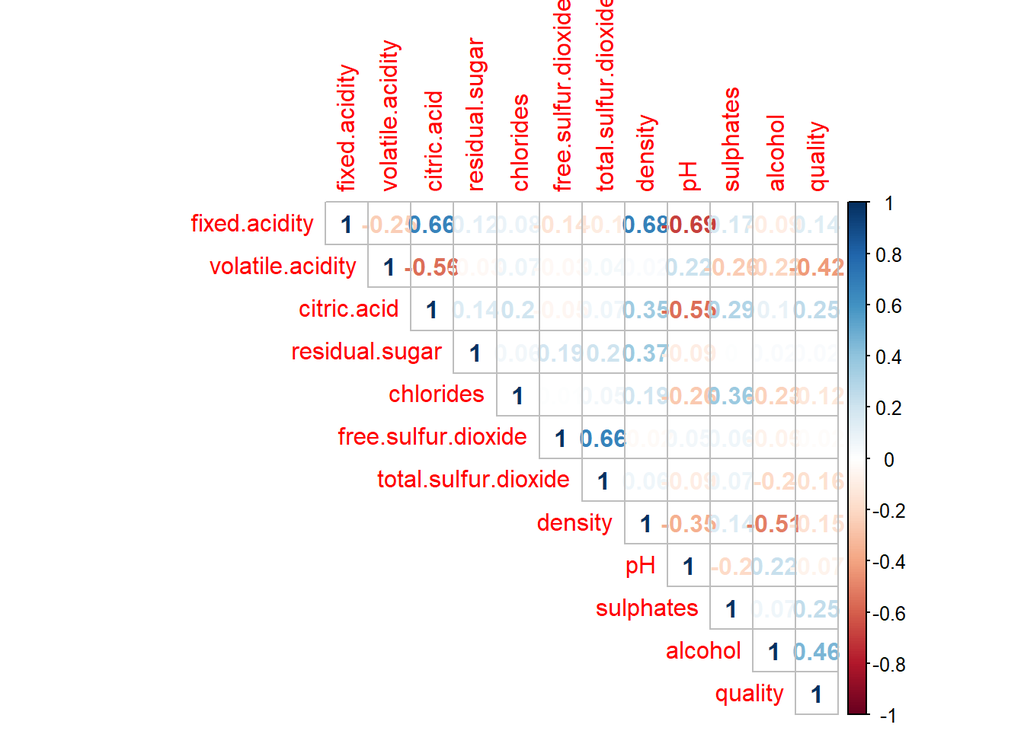

```r
m = cor(w_red_train[,1:12])
corrplot(m,method="number",type="upper")
```

We’d like to see now if there’s a difference between the means of these predictors at each quality value. For this, we use the following summarization:

```r
w_red_train %>% group_by(quality) %>% summarise(count=n(),fsd = mean(free.sulfur.dioxide),tsd = mean(total.sulfur.dioxide),d=mean(density),ca=mean(citric.acid))
```

```
## # A tibble: 6 x 6
##   quality count   fsd   tsd     d     ca
##     <dbl> <int> <dbl> <dbl> <dbl>  <dbl>
## 1       3     8  8.25  19.2 0.997 0.0788
## 2       4    45 12.4   38.0 0.997 0.172
## 3       5   505 16.8   56.2 0.997 0.239
## 4       6   479 16.1   41.7 0.997 0.271
## 5       7   152 14.5   36.0 0.996 0.378
## 6       8    11 12.8   32.7 0.995 0.431
```

From this we gather:

- Wines of higher quality has higher citric acid mean.
- Wine of the lowest quality has the lowest both citric acid mean, lowest free and total sulfure dioxide mean.
- There is small sample sizes of both low and high quality wine. We could have an unbalanced data problem.

This exploratory data analysis helped us understanding how to define our predictors.

# Model performance and selection

For this regression task, we will use the following algorithms:

- Decision Tree
- K nearest Neighbors
- Random Forest

We will evaluate this algorithms using RMSE loss function. The lower the RMSE is, the better the algorithm is. Each algorith will be cross-validated and fine tuned using caret package in R.